# Fixed Effects Panel Data Models

Theory, Intuition, and Application to Traffic Fatalities  
NYU - Applied Statistics and Econometrics 2

Author

Dragos Ailoae

# What This Notebook Covers

Along the way, we’ll cover:

- Why pooled OLS fails with omitted time-invariant variables
- The “within transformation” that eliminates fixed effects
- How to estimate FE models three different ways (LSDV, Within, First Difference)
- Two-way fixed effects (entity + time)
- Practical considerations: what drops out, when to cluster, how to interpret R²
- Testing and diagnostics for panel models

# 1 Introduction: The Omitted Variable Problem

## 1.1 The Classic Dilemma

Consider estimating the returns to education using a wage regression:

$$\log(wage_i) = \beta_0 + \beta_1 educ_i + \beta_2 exper_i + \varepsilon_i$$

**The problem:** High-ability people tend to get more education AND earn higher wages (even controlling for education). If ability is unobserved, it sits in the error term $\varepsilon_i$, creating omitted variable bias:

$$E[\hat{\beta}_1^{OLS}] = \beta_1 + \underbrace{\frac{Cov(educ, ability)}{Var(educ)}}_{\text{Upward bias > 0}}$$

**Traditional solutions:**

1. **Measure ability?** IQ tests are imperfect proxies → measurement error → still biased
2. **Find instruments?** Hard to find excludable instruments that only affect wages through education
3. **Just accept the bias?** Not if you care about causal inference!

## 1.2 The Panel Data Solution

**Key insight:** If we follow the **same people over time**, and if their ability doesn’t change, we can difference it away!

**Panel data structure:**

- **Cross-sectional data:** 10,000 people observed once (N = 10,000, T = 1)
- **Panel data:** 5,000 people observed twice (N = 5,000, T = 2)

By comparing Person A in 2010 to Person A in 2015, we eliminate bias from time-invariant characteristics:

- Person A’s ability in 2010 = Person A’s ability in 2015
- The difference eliminates ability: $ability_{2015} - ability_{2010} = 0$

This is the **fixed effects** approach.

## 1.3 When to Use Fixed Effects

**Fixed Effects is appropriate when:**

- You have **panel data** (repeated observations on the same units)
- You suspect **omitted time-invariant variables** correlate with your regressors
- You want to estimate effects of **time-varying** variables
- You’re willing to **control for** (but not estimate) time-invariant effects

**Fixed Effects CANNOT:**

- Estimate effects of time-invariant variables (gender, race, college attended)
- Handle endogeneity from time-varying omitted variables
- Guarantee causality if strict exogeneity fails

# 2 The Fixed Effects Model

## 2.1 Model Specification

For unit $i$ at time $t$:

$$y_{it} = \mathbf{x}_{it}'\boldsymbol{\beta} + \alpha_i + \varepsilon_{it}$$

where:

- $y_{it}$ = outcome variable
- $\mathbf{x}_{it}$ = $k \times 1$ vector of **time-varying** regressors
- $\boldsymbol{\beta}$ = $k \times 1$ vector of coefficients (what we want)
- $\alpha_i$ = individual-specific fixed effect (time-invariant, unobserved)
- $\varepsilon_{it}$ = idiosyncratic error (time-varying, unobserved)

## 2.2 Key Assumptions

1. **$\alpha_i$ is constant over time** for each unit $i$
2. **$\alpha_i$ may correlate with $\mathbf{x}_{it}$** (this is why pooled OLS is biased!)
3. **Strict exogeneity:** $E[\varepsilon_{it} | \mathbf{X}_i, \alpha_i] = 0$ for all $t$
4. Each unit has its own intercept: $\beta_0 + \alpha_i$

## 2.3 Two Types of Variation

Any variable can be decomposed as:

$$x_{it} = \bar{x}_i + (x_{it} - \bar{x}_i)$$

where $\bar{x}_i = \frac{1}{T}\sum_{t=1}^T x_{it}$ is the individual mean.

**Between variation:** Compares different units (uses $\bar{x}_1, \bar{x}_2, ..., \bar{x}_N$)

**Within variation:** Compares same unit over time (uses $x_{it} - \bar{x}_i$)

**The FE strategy:** Use only within variation → eliminate bias from time-invariant $\alpha_i$

# 3 The Fatalities Dataset

We’ll use the **Fatalities** dataset from the AER package to study the relationship between alcohol taxes and traffic fatalities in the United States.

## 3.1 Dataset Description

**Source:** Stock and Watson’s *Introduction to Econometrics*

**Structure:**

- **Entities:** 48 contiguous U.S. states
- **Time periods:** 7 years (1982-1988)
- **Total observations:** 336 (48 × 7, balanced panel)

**Key variables:**

- `fatal_rate`: Traffic fatalities per 10,000 people (our outcome)
- `beertax`: Tax on beer (in 1988 dollars)
- `drinkage`: Minimum legal drinking age
- `jail`, `service`: Punishment indicators
- `unemp`: Unemployment rate
- `income`: Real per capita income

**Research question:** Does increasing alcohol taxes reduce traffic fatalities?

# 4 Setup and Data Preparation

## 4.1 Load Required Packages

```r
# Clear workspace
rm(list = ls())

# Set plotting options
options(
  repr.plot.width = 8,
  repr.plot.height = 6,
  repr.plot.res = 150,
  warn = -1
)

# Required packages
packages <- c(
  "plm",           # Panel Linear Models
  "AER",           # Applied Econometrics with R (contains Fatalities data)
  "modelsummary",  # Beautiful regression tables
  "lmtest",        # Testing Linear Regression Models
  "car",           # Companion to Applied Regression (linearHypothesis)
  "knitr",         # Table formatting
  "fixest"         # Fast fixed effects estimation
)

# Install if needed, then load
invisible(lapply(packages, function(pkg) {
  if (!require(pkg, character.only = TRUE, quietly = TRUE)) {
    install.packages(pkg)
    require(pkg, character.only = TRUE, quietly = TRUE)
  }
}))
```

## 4.2 Load and Prepare Data

```r
# Load Fatalities data
data("Fatalities", package = "AER")

# Create fatality rate variable (fatalities per 10,000 people)
Fatalities$fatal_rate <- Fatalities$fatal / Fatalities$pop * 10000

# Create log income
Fatalities$log_income <- log(Fatalities$income)

# Discretize minimum legal drinking age
Fatalities$drinkagec <- cut(
  Fatalities$drinkage,
  breaks = 18:22,
  include.lowest = TRUE,
  right = FALSE
)
# Set [21,22] as baseline
Fatalities$drinkagec <- relevel(Fatalities$drinkagec, "[21,22]")

# Create punishment indicator
Fatalities$punish <- with(Fatalities,
  factor(jail == "yes" | service == "yes",
         labels = c("no", "yes"))
)

# Display structure
data.frame(
  Characteristic = c("States", "Years", "Total observations", "Panel type"),
  Value = as.character(c(
    length(unique(Fatalities$state)),
    length(unique(Fatalities$year)),
    nrow(Fatalities),
    ifelse(nrow(Fatalities) ==
      length(unique(Fatalities$state)) * length(unique(Fatalities$year)),
      "Balanced", "Unbalanced")
  ))
) |> kable(caption = "Dataset Structure")
```

Dataset Structure

| Characteristic | Value |
| --- | --- |
| States | 48 |
| Years | 7 |
| Total observations | 336 |
| Panel type | Balanced |

```r
# Summary statistics for key variables
summary(Fatalities[, c("fatal_rate", "beertax", "unemp", "income")])
```

```
   fatal_rate        beertax            unemp            income
 Min.   :0.8212   Min.   :0.04331   Min.   : 2.400   Min.   : 9514
 1st Qu.:1.6237   1st Qu.:0.20885   1st Qu.: 5.475   1st Qu.:12086
 Median :1.9560   Median :0.35259   Median : 7.000   Median :13763
 Mean   :2.0404   Mean   :0.51326   Mean   : 7.347   Mean   :13880
 3rd Qu.:2.4179   3rd Qu.:0.65157   3rd Qu.: 8.900   3rd Qu.:15175
 Max.   :4.2178   Max.   :2.72076   Max.   :18.000   Max.   :22193
```

## 4.3 Subset for 1982 and 1988 Comparison

```r
# Create subsets for specific years
Fatalities_1982 <- subset(Fatalities, year == "1982")
Fatalities_1988 <- subset(Fatalities, year == "1988")
Fatalities_1982_1988 <- subset(Fatalities, year %in% c("1982", "1988"))

data.frame(
  Subset = c("1982", "1988", "Combined 1982-1988"),
  Observations = as.character(c(nrow(Fatalities_1982), nrow(Fatalities_1988), nrow(Fatalities_1982_1988)))
) |> kable(caption = "Observations by Year Subset")
```

Observations by Year Subset

| Subset | Observations |
| --- | --- |
| 1982 | 48 |
| 1988 | 48 |
| Combined 1982-1988 | 96 |

# 5 Pooled OLS: The Naive Approach

## 5.1 Why Pooled OLS Fails

If we ignore the panel structure and just run OLS on all 336 observations:

```r
# Pooled OLS (ignoring panel structure)
pooled_ols <- lm(fatal_rate ~ beertax, data = Fatalities)

summary(pooled_ols)
```

```
Call:
lm(formula = fatal_rate ~ beertax, data = Fatalities)

Residuals:
     Min       1Q   Median       3Q      Max
-1.09060 -0.37768 -0.09436  0.28548  2.27643

Coefficients:
            Estimate Std. Error t value Pr(>|t|)
(Intercept)  1.85331    0.04357  42.539  < 2e-16 ***
beertax      0.36461    0.06217   5.865 1.08e-08 ***
---
Signif. codes:  0 '***' 0.001 '**' 0.01 '*' 0.05 '.' 0.1 ' ' 1

Residual standard error: 0.5437 on 334 degrees of freedom
Multiple R-squared:  0.09336,   Adjusted R-squared:  0.09065
F-statistic: 34.39 on 1 and 334 DF,  p-value: 1.082e-08
```

**Problem:** This treats all observations as independent, ignoring:

1. **Omitted state-specific factors** (culture, geography, institutions) → in error term
2. **Correlation within states** (observations from same state are not independent)
3. **Common time shocks** (recessions, federal policy changes)

**Result:** Biased estimates and incorrect standard errors.

## 5.2 Cross-Sectional Regressions (1982 vs 1988)

Let’s estimate separately for 1982 and 1988:

```r
# 1982 regression
model_1982 <- lm(fatal_rate ~ beertax, data = Fatalities_1982)

# 1988 regression
model_1988 <- lm(fatal_rate ~ beertax, data = Fatalities_1988)

# Compare using modelsummary
modelsummary(
  list("1982" = model_1982, "1988" = model_1988, "Pooled" = pooled_ols),
  stars = TRUE,
  gof_map = c("nobs", "r.squared", "adj.r.squared")
)
```

|  | 1982 | 1988 | Pooled |
| --- | --- | --- | --- |
| (Intercept) | 2.010*** | 1.859*** | 1.853*** |
|  | (0.139) | (0.106) | (0.044) |
| beertax | 0.148 | 0.439* | 0.365*** |
|  | (0.188) | (0.164) | (0.062) |
| Num.Obs. | 48 | 48 | 336 |
| R2 | 0.013 | 0.134 | 0.093 |
| R2 Adj. | -0.008 | 0.115 | 0.091 |

+ p < 0.1, * p < 0.05, ** p < 0.01, *** p < 0.001

**Observations:**

- Coefficient on `beertax` is **positive** in both years!
- Contradicts theory: higher beer tax should reduce drunk driving
- Likely omitted variable bias (states with high taxes differ systematically)

## 5.3 Visualization: Cross-Sectional Relationships

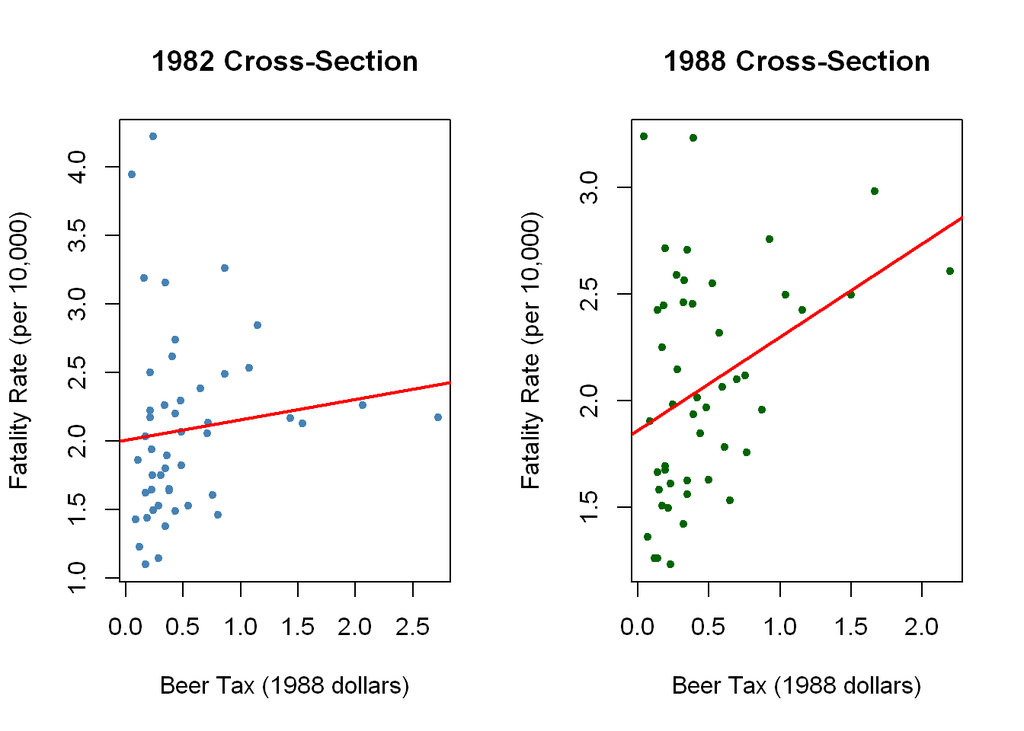

```r
par(mfrow = c(1, 2))

# 1982 scatter plot
plot(Fatalities_1982$beertax, Fatalities_1982$fatal_rate,
     xlab = "Beer Tax (1988 dollars)",
     ylab = "Fatality Rate (per 10,000)",
     main = "1982 Cross-Section",
     pch = 20, col = "steelblue")
abline(model_1982, col = "red", lwd = 2)

# 1988 scatter plot
plot(Fatalities_1988$beertax, Fatalities_1988$fatal_rate,
     xlab = "Beer Tax (1988 dollars)",
     ylab = "Fatality Rate (per 10,000)",
     main = "1988 Cross-Section",
     pch = 20, col = "darkgreen")
abline(model_1988, col = "red", lwd = 2)
```

**Key insight:** Cross-sectional comparisons are contaminated by state-level heterogeneity. We need to control for unobserved state characteristics.

# 6 Fixed Effects Estimation: Method 1 - LSDV

## 6.1 Least Squares Dummy Variable Approach

**Idea:** Include a dummy variable for each state.

**Model:**
$$y_{it} = \mathbf{x}_{it}'\boldsymbol{\beta} + \sum_{j=1}^N \alpha_j D_{ij} + \varepsilon_{it}$$

where $D_{ij} = 1$ if $i = j$, and 0 otherwise.

```r
# LSDV estimation (dummy variable for each state, omit intercept)
lsdv_model <- lm(fatal_rate ~ beertax + state - 1, data = Fatalities)

# Display coefficients (just show first few states and beertax)
summary(lsdv_model)$coefficients[c(1, 2:5, 48:49), ]
```

```
          Estimate Std. Error   t value      Pr(>|t|)
beertax -0.6558737 0.18784999 -3.491476  5.559697e-04
stateal  3.4776301 0.31335679 11.097989  4.751833e-24
stateaz  2.9099032 0.09253893 31.445179  5.672947e-95
statear  2.8226785 0.13212532 21.363646  2.902574e-61
stateca  1.9681613 0.07400678 26.594335  2.045800e-79
statewi  1.7183637 0.07745691 22.184770  3.379201e-64
statewy  3.2491264 0.07232833 44.921907 7.322466e-132
```

**Note:** We estimate 49 parameters:

- 1 coefficient on `beertax` (our parameter of interest)
- 48 state fixed effects (48 states)

```r
# Extract the beer tax coefficient
beertax_lsdv <- coef(lsdv_model)["beertax"]
se_lsdv <- summary(lsdv_model)$coefficients["beertax", "Std. Error"]

data.frame(
  Parameter = c("β_beertax", "SE"),
  Value = as.character(c(round(beertax_lsdv, 4), round(se_lsdv, 4)))
) |> kable(caption = "LSDV Estimate")
```

LSDV Estimate

| Parameter | Value |
| --- | --- |
| β_beertax | -0.6559 |
| SE | 0.1878 |

**Interpretation:**

- Coefficient is now **negative**: higher beer tax → fewer fatalities
- Sign reversal shows the importance of controlling for state effects
- Each state has its own intercept (captured by dummy coefficients)

## 6.2 Computational Issue with LSDV

**Problem:** With many entities (N large), LSDV becomes computationally expensive:

- Inverting a $(k + N) \times (k + N)$ matrix
- With 48 states: manageable
- With 10,000 individuals: prohibitively slow

**Solution:** Use the “within transformation” instead (same answer, much faster).

# 7 Fixed Effects Estimation: Method 2 - Within Transformation

## 7.1 The Demeaning Approach

**Step 1:** Calculate individual means:
$$\bar{y}_i = \frac{1}{T}\sum_{t=1}^T y_{it}, \quad \bar{x}_i = \frac{1}{T}\sum_{t=1}^T x_{it}$$

**Step 2:** Subtract means (demean):
$$\tilde{y}_{it} = y_{it} - \bar{y}_i, \quad \tilde{x}_{it} = x_{it} - \bar{x}_i$$

**Step 3:** Run OLS on demeaned data:
$$\tilde{y}_{it} = \tilde{\mathbf{x}}_{it}'\boldsymbol{\beta} + \tilde{\varepsilon}_{it}$$

**Why this works:**

Starting with: $y_{it} = \mathbf{x}_{it}'\boldsymbol{\beta} + \alpha_i + \varepsilon_{it}$

Take time average: $\bar{y}_i = \bar{\mathbf{x}}_i'\boldsymbol{\beta} + \alpha_i + \bar{\varepsilon}_i$

Subtract: $(y_{it} - \bar{y}_i) = (\mathbf{x}_{it} - \bar{\mathbf{x}}_i)'\boldsymbol{\beta} + \underbrace{(\alpha_i - \alpha_i)}_{= 0} + (\varepsilon_{it} - \bar{\varepsilon}_i)$

**The fixed effect $\alpha_i$ disappears!**

## 7.2 Manual Demeaning

```r
# Manually demean the data
Fatalities_demeaned <- with(Fatalities,
  data.frame(
    fatal_rate_dm = fatal_rate - ave(fatal_rate, state),
    beertax_dm = beertax - ave(beertax, state)
  )
)

# Run OLS on demeaned data (no intercept!)
within_manual <- lm(fatal_rate_dm ~ beertax_dm - 1, data = Fatalities_demeaned)

summary(within_manual)
```

```
Call:
lm(formula = fatal_rate_dm ~ beertax_dm - 1, data = Fatalities_demeaned)

Residuals:
     Min       1Q   Median       3Q      Max
-0.58696 -0.08284 -0.00127  0.07955  0.89780

Coefficients:
           Estimate Std. Error t value Pr(>|t|)
beertax_dm  -0.6559     0.1739  -3.772 0.000191 ***
---
Signif. codes:  0 '***' 0.001 '**' 0.01 '*' 0.05 '.' 0.1 ' ' 1

Residual standard error: 0.1757 on 335 degrees of freedom
Multiple R-squared:  0.04074,   Adjusted R-squared:  0.03788
F-statistic: 14.23 on 1 and 335 DF,  p-value: 0.0001913
```

## 7.3 Using plm() Package

The `plm` package provides convenient panel data functions:

```r
# Estimate using plm() with "within" model
fe_within <- plm(
  fatal_rate ~ beertax,
  data = Fatalities,
  index = c("state", "year"),
  model = "within"
)

# Summary with robust standard errors
coeftest(fe_within, vcov = vcovHC(fe_within, type = "HC1"))
```

```
t test of coefficients:

        Estimate Std. Error t value Pr(>|t|)
beertax -0.65587    0.28880  -2.271  0.02388 *
---
Signif. codes:  0 '***' 0.001 '**' 0.01 '*' 0.05 '.' 0.1 ' ' 1
```

## 7.4 Comparing LSDV and Within

```r
# Extract coefficients
coef_lsdv <- coef(lsdv_model)["beertax"]
coef_within_manual <- coef(within_manual)["beertax_dm"]
coef_within_plm <- coef(fe_within)["beertax"]

# Create comparison table
comparison_df <- data.frame(
  Method = c("LSDV", "Within (manual)", "Within (plm)"),
  Coefficient = c(coef_lsdv, coef_within_manual, coef_within_plm),
  Difference_from_LSDV = c(0,
                           coef_within_manual - coef_lsdv,
                           coef_within_plm - coef_lsdv)
)

kable(comparison_df, digits = 6,
      caption = "Comparison of LSDV and Within Estimators")
```

Comparison of LSDV and Within Estimators

|  | Method | Coefficient | Difference_from_LSDV |
| --- | --- | --- | --- |
|  | LSDV | -0.655874 | 0 |
| beertax_dm | Within (manual) | -0.655874 | 0 |
| beertax | Within (plm) | -0.655874 | 0 |

**Frisch-Waugh-Lovell Theorem:** LSDV and Within are **numerically identical** (differences are just rounding error).

# 8 Fixed Effects Estimation: Method 3 - First Differencing

## 8.1 The Differencing Approach

**Idea:** Subtract the previous period from the current period.

At time $t$: $y_{it} = \mathbf{x}_{it}'\boldsymbol{\beta} + \alpha_i + \varepsilon_{it}$

At time $t-1$: $y_{it-1} = \mathbf{x}_{it-1}'\boldsymbol{\beta} + \alpha_i + \varepsilon_{it-1}$

**Subtract:**
$$\Delta y_{it} = \Delta \mathbf{x}_{it}'\boldsymbol{\beta} + \Delta \varepsilon_{it}$$

where $\Delta y_{it} = y_{it} - y_{it-1}$ and $\Delta \varepsilon_{it} = \varepsilon_{it} - \varepsilon_{it-1}$

**Note:** Fixed effect $\alpha_i$ disappears: $\alpha_i - \alpha_i = 0$

```r
# Estimate using first differences with plm
fe_fd <- plm(
  fatal_rate ~ beertax,
  data = Fatalities,
  index = c("state", "year"),
  model = "fd"  # First Difference
)

summary(fe_fd)
```

```
Oneway (individual) effect First-Difference Model

Call:
plm(formula = fatal_rate ~ beertax, data = Fatalities, model = "fd",
    index = c("state", "year"))

Balanced Panel: n = 48, T = 7, N = 336
Observations used in estimation: 288

Residuals:
     Min.   1st Qu.    Median   3rd Qu.      Max.
-0.697391 -0.106403  0.010073  0.109465  0.606420

Coefficients:
              Estimate Std. Error t-value Pr(>|t|)
(Intercept) -0.0031368  0.0119115 -0.2633   0.7925
beertax      0.0136878  0.2852511  0.0480   0.9618

Total Sum of Squares:    11.213
Residual Sum of Squares: 11.213
R-Squared:      8.0509e-06
Adj. R-Squared: -0.0034884
F-statistic: 0.00230256 on 1 and 286 DF, p-value: 0.96176
```

## 8.2 Comparing Within and First Difference

```r
# Side-by-side comparison
modelsummary(
  list("Within (FE)" = fe_within, "First Difference" = fe_fd),
  stars = TRUE,
  gof_map = c("nobs", "r.squared")
)
```

|  | Within (FE) | First Difference |
| --- | --- | --- |
| beertax | -0.656*** | 0.014 |
|  | (0.188) | (0.285) |
| (Intercept) |  | -0.003 |
|  |  | (0.012) |
| Num.Obs. | 336 | 288 |
| R2 | 0.041 | 0.000 |

+ p < 0.1, * p < 0.05, ** p < 0.01, *** p < 0.001

**⚠️ Important observation:** The FD estimate is **completely different** from Within!

- Within: -0.656*** (negative, highly significant)
- FD: 0.014 (near zero, insignificant, R² ≈ 0)

**Why such a dramatic difference?**

The answer reveals something important about **what variation each estimator uses** and **what question each one answers**.

```r
# Examine variation in beer tax
library(dplyr)

tax_variation <- Fatalities %>%
  arrange(state, year) %>%
  group_by(state) %>%
  mutate(
    beertax_change = beertax - lag(beertax),
    beertax_deviation = beertax - mean(beertax)
  ) %>%
  ungroup()

# Compare variation used by each estimator
data.frame(
  Estimator = c("Within", "First Difference"),
  Metric = c("SD of deviations from state means", "SD of year-to-year changes"),
  Value = as.character(c(
    round(sd(tax_variation$beertax_deviation, na.rm = TRUE), 4),
    round(sd(tax_variation$beertax_change, na.rm = TRUE), 4)
  ))
) |> kable(caption = "Variation Used by Each Estimator")
```

Variation Used by Each Estimator

| Estimator | Metric | Value |
| --- | --- | --- |
| Within | SD of deviations from state means | 0.0552 |
| First Difference | SD of year-to-year changes | 0.041 |

```r
# Analyze change patterns
zero_changes <- mean(tax_variation$beertax_change == 0, na.rm = TRUE) * 100
small_changes <- mean(abs(tax_variation$beertax_change) < 0.05, na.rm = TRUE) * 100
mean_abs_change <- mean(abs(tax_variation$beertax_change), na.rm = TRUE)

data.frame(
  Characteristic = c("Mean absolute change", "% of periods with NO change", "% of periods with small change (<$0.05)"),
  Value = c(
    as.character(round(mean_abs_change, 4)),
    paste0(round(zero_changes, 1), "%"),
    paste0(round(small_changes, 1), "%")
  )
) |> kable(caption = "Beer Tax Change Patterns")
```

Beer Tax Change Patterns

| Characteristic | Value |
| --- | --- |
| Mean absolute change | 0.024 |
| % of periods with NO change | 0% |
| % of periods with small change (<$0.05) | 89.2% |

## 8.3 Understanding the Difference

**The key insight:** Within and FD answer **different questions**!

**Within estimator asks:** “Do states with higher-than-average beer taxes (over the 7-year period) have lower-than-average fatality rates?”

- Uses deviations from each state’s 7-year average
- Example: If State A averages $0.50 over 1982-1988, Within uses:
  - (0.48, 0.49, 0.50, 0.51, 0.52, 0.51, 0.50) - 0.50 = (-0.02, -0.01, 0, +0.01, +0.02, +0.01, 0)
- Captures **persistent within-state variation** across multiple years
- **Answer from our data:** Yes! Coefficient = -0.656***

**FD estimator asks:** “When a state increases its beer tax from one year to the next, do fatalities decrease?”

- Uses only year-to-year differences
- Same state: (0.49-0.48, 0.50-0.49, 0.51-0.50, 0.52-0.51, 0.51-0.52, 0.50-0.51)
  - = (0.01, 0.01, 0.01, 0.01, -0.01, -0.01)
- Captures **short-run dynamic effects** of tax changes
- **Answer from our data:** No clear relationship! Coefficient ≈ 0

**Why the different answers?**

Several possible explanations:

1. **Lagged effects:** Tax changes may take time to affect behavior
   - Within captures cumulative effects over years
   - FD only captures immediate year-to-year response
2. **Endogeneity of tax changes:** States may change taxes in response to recent fatality trends
   - If fatalities increased → state raises taxes → FD sees positive correlation
   - This could mask or reverse the true causal effect
3. **Measurement error:** FD is more sensitive to noise
   - Differencing amplifies measurement error in tax data
   - Could bias FD estimates toward zero
4. **Different causal parameters:**
   - Within estimates: effect of **persistent** tax differences
   - FD estimates: effect of **short-run** tax changes
   - These need not be the same!

**Implication:** The negative Within coefficient tells us that states with consistently higher beer taxes have fewer traffic fatalities. But FD suggests that year-to-year tax adjustments don’t have an immediate detectable effect. Both findings can be true simultaneously!

## 8.4 Testing with a More Time-Varying Regressor

Let’s verify this diagnosis by using unemployment, which varies more year-to-year:

```r
# Within estimator with unemployment
fe_within_unemp <- plm(
  fatal_rate ~ unemp,
  data = Fatalities,
  index = c("state", "year"),
  model = "within"
)

# FD estimator with unemployment
fe_fd_unemp <- plm(
  fatal_rate ~ unemp,
  data = Fatalities,
  index = c("state", "year"),
  model = "fd"
)

modelsummary(
  list("Within (unemp)" = fe_within_unemp,
       "FD (unemp)" = fe_fd_unemp),
  stars = TRUE,
  gof_map = c("nobs", "r.squared")
)
```

|  | Within (unemp) | FD (unemp) |
| --- | --- | --- |
| unemp | -0.034*** | -0.030** |
|  | (0.006) | (0.011) |
| (Intercept) |  | -0.022+ |
|  |  | (0.013) |
| Num.Obs. | 336 | 288 |
| R2 | 0.095 | 0.027 |

+ p < 0.1, * p < 0.05, ** p < 0.01, *** p < 0.001

**Observation:** With unemployment (which varies substantially year-to-year), Within and FD give more similar results:

- Both are **negative and significant** (same sign, both reject H₀)
- **Magnitudes are close:** -0.034 vs -0.030 (Within vs FD)
- **FD is less efficient:** Lower R², larger standard errors

This makes sense because unemployment changes reflect actual year-to-year economic fluctuations that plausibly affect driving behavior in the short run. Unlike tax policy (which may be endogenous or have lags), unemployment shocks are more exogenous and have immediate effects.

**The key difference from beer tax:** - **Beer tax FD:** Near zero, R² ≈ 0 (no relationship between changes) - **Unemployment FD:** Negative, R² = 0.027 (clear relationship between changes)

This confirms that the beer tax result isn’t a general failure of FD - it’s specific to variables where short-run changes don’t have immediate effects or are endogenous.

## 8.5 When Each Estimator Works Best

**Key lessons from this comparison:**

1. **Within and FD answer different questions:**
   - **Within:** “Do units with higher levels of X (relative to their average) have higher levels of Y?”
   - **FD:** “When X increases from one period to the next, does Y also increase?”
2. **When Within is preferred:**
   - Short panels (T < 10) - more identifying variation
   - Interest in cumulative/persistent effects
   - Errors are approximately i.i.d. over time
   - **Most common choice for applied work**
3. **When FD might be better:**
   - Strong theoretical interest in **short-run dynamics** (changes → changes)
   - Suspected random walk in errors (AR(1) with ρ ≈ 1)
   - Very long panels where Within might be contaminated by trends
   - Want robustness to certain violations of strict exogeneity
4. **Important caveats:**
   - **FD is more sensitive to measurement error** (differencing amplifies noise)
   - **FD creates MA(1) errors by construction:** $Cov(\Delta\varepsilon_{it}, \Delta\varepsilon_{it-1}) \neq 0$
   - **FD loses observations** (first period for each unit)
   - **FD may suffer from reverse causality** if policy changes respond to recent outcomes

**For beer taxes:**

The Within estimator is clearly more appropriate if we’re interested in the overall deterrent effect of alcohol taxation. The fact that FD gives a near-zero estimate suggests either:

- Tax changes don’t have immediate effects (there are lags)
- Tax changes are endogenous to recent fatality trends
- The true causal effect operates through persistent tax differences, not year-to-year adjustments

**Default recommendation:** Use Within for most applications. Use FD as a robustness check or when you have specific theoretical reasons to focus on short-run dynamics.

# 9 Two-Way Fixed Effects

## 9.1 Adding Time Fixed Effects

So far we’ve controlled for **state effects** (entity fixed effects). We can also control for **time effects** (common shocks affecting all states in a given year).

**One-way FE:**
$$y_{it} = \mathbf{x}_{it}'\boldsymbol{\beta} + \alpha_i + \varepsilon_{it}$$

**Two-way FE (entity + time):**
$$y_{it} = \mathbf{x}_{it}'\boldsymbol{\beta} + \alpha_i + \lambda_t + \varepsilon_{it}$$

**What $\lambda_t$ captures:**

- Macroeconomic shocks (recessions, oil crises)
- Federal policy changes affecting all states
- National trends (technology, social attitudes)

## 9.2 Estimation with plm()

```r
# Two-way fixed effects (state + year)
fe_twoway <- plm(
  fatal_rate ~ beertax,
  data = Fatalities,
  index = c("state", "year"),
  model = "within",
  effect = "twoways"  # Include both state and time effects
)

# Robust standard errors
coeftest(fe_twoway, vcov = vcovHC(fe_twoway, type = "HC1"))
```

```
t test of coefficients:

        Estimate Std. Error t value Pr(>|t|)
beertax -0.63998    0.35015 -1.8277  0.06865 .
---
Signif. codes:  0 '***' 0.001 '**' 0.01 '*' 0.05 '.' 0.1 ' ' 1
```

## 9.3 LSDV Representation

We can also estimate two-way FE using LSDV by including both state and year dummies:

```r
# LSDV with state and year dummies
lsdv_twoway <- lm(
  fatal_rate ~ beertax + state + year - 1,
  data = Fatalities
)

# Extract beertax coefficient
coef_twoway_lsdv <- coef(lsdv_twoway)["beertax"]
se_twoway_lsdv <- summary(lsdv_twoway)$coefficients["beertax", "Std. Error"]

data.frame(
  Parameter = c("β_beertax", "SE"),
  Value = as.character(c(round(coef_twoway_lsdv, 4), round(se_twoway_lsdv, 4)))
) |> kable(caption = "Two-way FE via LSDV")
```

Two-way FE via LSDV

| Parameter | Value |
| --- | --- |
| β_beertax | -0.64 |
| SE | 0.1974 |

## 9.4 Comparison: One-Way vs Two-Way FE

```r
modelsummary(
  list(
    "Pooled OLS" = pooled_ols,
    "State FE" = fe_within,
    "State + Time FE" = fe_twoway
  ),
  stars = TRUE,
  gof_map = c("nobs", "r.squared")
)
```

|  | Pooled OLS | State FE | State + Time FE |
| --- | --- | --- | --- |
| (Intercept) | 1.853*** |  |  |
|  | (0.044) |  |  |
| beertax | 0.365*** | -0.656*** | -0.640** |
|  | (0.062) | (0.188) | (0.197) |
| Num.Obs. | 336 | 336 | 336 |
| R2 | 0.093 | 0.041 | 0.036 |

+ p < 0.1, * p < 0.05, ** p < 0.01, *** p < 0.001

**Observations:**

1. **Sign changes:** Pooled OLS is positive (wrong sign!), FE is negative (expected)
2. **Magnitude:** Two-way FE estimate (-0.640) is similar to one-way FE (-0.656)
3. **Precision:** Standard errors increase slightly with two-way FE (less variation to use)

**Interpretation:** Including time effects doesn’t dramatically change the estimate, suggesting year-to-year common shocks are not the main confound. State heterogeneity is the primary concern.

# 10 Adding Control Variables

## 10.1 Extended Model Specification

Let’s add covariates that might explain fatalities:

**Economic conditions:**

- `unemp`: Unemployment rate
- `log(income)`: Log real per capita income
- `miles`: Average miles per driver

**Legal framework:**

- `drinkagec`: Minimum legal drinking age categories
- `punish`: Mandatory jail/community service for first offense

```r
# Full model with covariates (two-way FE)
fe_full <- plm(
  fatal_rate ~ beertax + drinkagec + punish + miles + unemp + log_income,
  data = Fatalities,
  index = c("state", "year"),
  model = "within",
  effect = "twoways"
)

# Robust standard errors
coeftest(fe_full, vcov = vcovHC(fe_full, type = "HC1"))
```

```
t test of coefficients:

                    Estimate  Std. Error t value  Pr(>|t|)
beertax          -4.4534e-01  2.9137e-01 -1.5285  0.127558
drinkagec[18,19)  2.8446e-02  6.8426e-02  0.4157  0.677947
drinkagec[19,20) -1.7953e-02  4.8994e-02 -0.3664  0.714325
drinkagec[20,21)  3.2021e-02  4.9519e-02  0.6466  0.518402
punishyes         3.8331e-02  1.0094e-01  0.3797  0.704428
miles             8.2281e-06  6.7068e-06  1.2268  0.220944
unemp            -6.3260e-02  1.2955e-02 -4.8830 1.781e-06 ***
log_income        1.8158e+00  6.2364e-01  2.9116  0.003893 **
---
Signif. codes:  0 '***' 0.001 '**' 0.01 '*' 0.05 '.' 0.1 ' ' 1
```

## 10.2 Model without Economic Variables

```r
# Model excluding economic variables
fe_no_econ <- plm(
  fatal_rate ~ beertax + drinkagec + punish + miles,
  data = Fatalities,
  index = c("state", "year"),
  model = "within",
  effect = "twoways"
)
```

## 10.3 Comprehensive Comparison Table

```r
modelsummary(
  list(
    "Pooled OLS" = pooled_ols,
    "State FE" = fe_within,
    "State+Time FE" = fe_twoway,
    "Full Model" = fe_full,
    "No Econ Controls" = fe_no_econ
  ),
  stars = TRUE,
  coef_omit = "drinkagec|punish",  # Omit dummy variables for cleaner table
  gof_map = c("nobs", "r.squared", "adj.r.squared")
)
```

|  | Pooled OLS | State FE | State+Time FE | Full Model | No Econ Controls |
| --- | --- | --- | --- | --- | --- |
| (Intercept) | 1.853*** |  |  |  |  |
|  | (0.044) |  |  |  |  |
| beertax | 0.365*** | -0.656*** | -0.640** | -0.445** | -0.690*** |
|  | (0.062) | (0.188) | (0.197) | (0.169) | (0.200) |
| miles |  |  |  | 0.000 | 0.000 |
|  |  |  |  | (0.000) | (0.000) |
| unemp |  |  |  | -0.063*** |  |
|  |  |  |  | (0.011) |  |
| log_income |  |  |  | 1.816*** |  |
|  |  |  |  | (0.380) |  |
| Num.Obs. | 336 | 336 | 336 | 335 | 335 |
| R2 | 0.093 | 0.041 | 0.036 | 0.360 | 0.066 |
| R2 Adj. | 0.091 | -0.120 | -0.149 | 0.217 | -0.134 |

+ p < 0.1, * p < 0.05, ** p < 0.01, *** p < 0.001

**Important caveats for causal interpretation:**

⚠️ **This is NOT a randomized experiment.** States choose their tax policies, potentially in response to traffic conditions.

⚠️ **Reverse causality possible:** High-fatality states might increase taxes → would bias FE estimates toward zero (our estimates could be lower bounds).

⚠️ **Time-varying confounds remain:** FE only controls for time-invariant state characteristics. Unobserved factors that change over time (cultural shifts, vehicle safety improvements) could still bias estimates.

⚠️ **Strict exogeneity required:** FE assumes beer tax at time t is uncorrelated with past and future error terms. If states adjust taxes based on recent fatality trends, this assumption fails.

**Bottom line:** The negative relationship is robust across specifications, suggesting beer taxes do reduce fatalities. But the exact magnitude should be interpreted cautiously given potential remaining biases.

# 11 Hypothesis Testing with Fixed Effects

## 11.1 Testing Drinking Age Effects

```r
# Test joint significance of drinking age categories
linearHypothesis(
  fe_full,
  c("drinkagec[18,19) = 0",
    "drinkagec[19,20) = 0",
    "drinkagec[20,21) = 0"),
  vcov = vcovHC(fe_full, type = "HC1")
)
```

|  | Res.Df | Df | Chisq | Pr(>Chisq) |
| --- | --- | --- | --- | --- |
| 1 | 276 | NA | NA | NA |
| 2 | 273 | 3 | 1.107388 | 0.7752909 |

**Interpretation:** Cannot reject null hypothesis that all drinking age coefficients are zero (p > 0.05). Minimum legal drinking age does not significantly affect fatality rates in this model.

## 11.2 Testing Economic Variables

```r
# Test joint significance of economic variables
linearHypothesis(
  fe_full,
  c("unemp = 0", "log_income = 0"),
  vcov = vcovHC(fe_full, type = "HC1")
)
```

|  | Res.Df | Df | Chisq | Pr(>Chisq) |
| --- | --- | --- | --- | --- |
| 1 | 275 | NA | NA | NA |
| 2 | 273 | 2 | 61.64672 | 4.107564e-14 |

**Interpretation:** Strong rejection (p < 0.001). Economic conditions jointly explain fatality rates. This justifies including them in the model.

## 11.3 Testing Punishment Effect

```r
# Single coefficient test (already in summary)
coeftest(fe_full, vcov = vcovHC(fe_full, type = "HC1"))["punishyes", ]
```

```
  Estimate Std. Error    t value   Pr(>|t|)
0.03833104 0.10093812 0.37974789 0.70442781
```

**Interpretation:** No evidence that mandatory punishment for first offenders reduces fatalities (p > 0.10).

# 12 Understanding R-squared in Panel Models

## 12.1 Three Types of R²

```r
# Show all three R-squared values
summary(fe_full)
```

```
Twoways effects Within Model

Call:
plm(formula = fatal_rate ~ beertax + drinkagec + punish + miles +
    unemp + log_income, data = Fatalities, effect = "twoways",
    model = "within", index = c("state", "year"))

Unbalanced Panel: n = 48, T = 6-7, N = 335

Residuals:
      Min.    1st Qu.     Median    3rd Qu.       Max.
-0.4298676 -0.0760229  0.0046877  0.0835909  0.4932074

Coefficients:
                    Estimate  Std. Error t-value  Pr(>|t|)
beertax          -4.4534e-01  1.6874e-01 -2.6392  0.008788 **
drinkagec[18,19)  2.8446e-02  6.5755e-02  0.4326  0.665648
drinkagec[19,20) -1.7953e-02  3.9940e-02 -0.4495  0.653427
drinkagec[20,21)  3.2021e-02  4.5108e-02  0.7099  0.478383
punishyes         3.8331e-02  5.9861e-02  0.6403  0.522489
miles             8.2281e-06  8.8215e-06  0.9327  0.351780
unemp            -6.3260e-02  1.1159e-02 -5.6689 3.651e-08 ***
log_income        1.8158e+00  3.8014e-01  4.7766 2.914e-06 ***
---
Signif. codes:  0 '***' 0.001 '**' 0.01 '*' 0.05 '.' 0.1 ' ' 1

Total Sum of Squares:    10.289
Residual Sum of Squares: 6.5853
R-Squared:      0.35999
Adj. R-Squared: 0.21698
F-statistic: 19.1942 on 8 and 273 DF, p-value: < 2.22e-16
```

**Within R²:** Variation explained after removing individual means

- Measures fit using only within-unit variation
- This is what FE estimates use
- Report this for FE models

**Between R²:** How well model fits individual means

- Uses only between variation (cross-sectional)
- Often low for FE (we deliberately ignore this variation!)

**Overall R²:** Total variation explained (all NT observations)

- Combines both within and between
- Can be misleading for FE models

## 12.2 Common Misconceptions

**Mistake 1:** “My within R² is only 0.36, the model is terrible!”

- **Reality:** That’s 36% of variation AFTER removing state effects
- Much of the variation is between states (which FE controls for)
- Within R² of 0.20-0.40 is often good for panel models

**Mistake 2:** Comparing FE R² to cross-sectional R²

- **Problem:** They measure different things
- Cross-sectional R² uses all variation
- Within R² uses only time variation within units

**What to report:** Always report Within R² for fixed effects models.

## 12.3 Comparing R² Reporting: plm vs fixest

Different R packages report different R² values as their “primary” statistic. Let’s compare `plm` (which emphasizes Within R²) with `fixest` (which emphasizes Overall R²).

### 12.3.1 Estimating with fixest

The `fixest` package is increasingly popular for fixed effects models due to its speed and clean syntax:

```r
# Estimate the same model with fixest
# Syntax: outcome ~ covariates | fixed effects
fe_fixest <- feols(
  fatal_rate ~ beertax + drinkagec + punish + miles + unemp + log_income | state + year,
  data = Fatalities,
  vcov = "iid"  # Matches PLM
)

# Display summary
summary(fe_fixest)
```

```
OLS estimation, Dep. Var.: fatal_rate
Observations: 335
Fixed-effects: state: 48,  year: 7
Standard-errors: IID
                    Estimate Std. Error   t value   Pr(>|t|)
beertax          -0.44534439 0.16874265 -2.639193 8.7880e-03 **
drinkagec[18,19)  0.02844566 0.06575540  0.432598 6.6565e-01
drinkagec[19,20) -0.01795314 0.03994012 -0.449501 6.5343e-01
drinkagec[20,21)  0.03202128 0.04510785  0.709883 4.7838e-01
punishyes         0.03833104 0.05986050  0.640339 5.2249e-01
miles             0.00000823 0.00000882  0.932737 3.5178e-01
unemp            -0.06325982 0.01115905 -5.668925 3.6509e-08 ***
log_income        1.81577049 0.38013917  4.776594 2.9136e-06 ***
---
Signif. codes:  0 '***' 0.001 '**' 0.01 '*' 0.05 '.' 0.1 ' ' 1
RMSE: 0.140206     Adj. R2: 0.926015
                 Within R2: 0.359987
```

### 12.3.2 Understanding fixest’s R² Reporting

```r
# Re-estimate fixest with explicitly non-clustered SEs (for comparison purposes)
# Must use vcov = "iid" to override fixest's automatic clustering
fe_fixest_naive <- feols(
  fatal_rate ~ beertax + drinkagec + punish + miles + unemp + log_income | state + year,
  data = Fatalities,
  vcov = "iid"  # Explicitly request non-clustered (classical) SEs
)

# Create comparison table using the naive fixest model
data.frame(
  Package = rep(c("fixest", "plm"), c(3, 3)),
  R_squared_Type = c("Overall R²", "Within R²", "Adjusted Overall R²",
                     "Within R²", "Adjusted Within R²", "Overall R²"),
  Value = as.character(c(
    round(r2(fe_fixest_naive, type = "r2"), 4),
    round(r2(fe_fixest_naive, type = "wr2"), 4),
    round(r2(fe_fixest_naive, type = "ar2"), 4),
    round(summary(fe_full)$r.squared[1], 4),
    round(summary(fe_full)$r.squared[2], 4),
    ifelse(is.na(summary(fe_full)$r.squared[3]),
           "NA (two-way FE)",
           as.character(round(summary(fe_full)$r.squared[3], 4)))
  ))
) |> kable(caption = "R² Values: fixest vs plm")
```

R² Values: fixest vs plm

| Package | R_squared_Type | Value |
| --- | --- | --- |
| fixest | Overall R² | 0.9395 |
| fixest | Within R² | 0.36 |
| fixest | Adjusted Overall R² | 0.926 |
| plm | Within R² | 0.36 |
| plm | Adjusted Within R² | 0.217 |
| plm | Overall R² | NA (two-way FE) |

### 12.3.3 Side-by-Side Comparison with modelsummary

For this comparison, we use classical (non-clustered) standard errors for both models to focus purely on the R² differences. (In practice, always use clustered SEs!)

```r
# Create a comparison table with consistent SEs
modelsummary(
  list("plm (State+Time FE)" = fe_full,
       "fixest (State+Time FE)" = fe_fixest_naive),
  stars = TRUE,
  coef_omit = "drinkagec|punish",
  gof_map = c("nobs", "r.squared", "adj.r.squared"),
  notes = "Note: Using classical (non-clustered) SEs."
)
```

|  | plm (State+Time FE) | fixest (State+Time FE) |
| --- | --- | --- |
| beertax | -0.445** | -0.445** |
|  | (0.169) | (0.169) |
| miles | 0.000 | 0.000 |
|  | (0.000) | (0.000) |
| unemp | -0.063*** | -0.063*** |
|  | (0.011) | (0.011) |
| log_income | 1.816*** | 1.816*** |
|  | (0.380) | (0.380) |
| Num.Obs. | 335 | 335 |
| R2 | 0.360 | 0.940 |
| R2 Adj. | 0.217 | 0.926 |

+ p < 0.1, * p < 0.05, ** p < 0.01, *** p < 0.001  
Note: Using classical (non-clustered) SEs.

**Key observation from the table:**

- **Coefficients:** Identical across both packages (as expected)
- **Standard errors:** Should be identical or very similar (both using classical SEs)
  - *Note: Any minor differences are due to degrees of freedom adjustments*
- **R² reported by plm:** Within R² = 0.360
- **R² reported by fixest:** Overall R² = 0.940 (much higher!)
- **Within R² for fixest:** Can be accessed separately, matches plm

The massive difference in reported R² (0.360 vs 0.940) reflects the different defaults:

- `plm` emphasizes **Within R²** = variance explained by time-varying covariates
- `fixest` emphasizes **Overall R²** = variance explained by full model including fixed effects

Both are “correct” - they’re just answering different questions about model fit.

### 12.3.4 Key Differences in Philosophy

**plm approach:**

- Primary focus: **Within R²** (variation explained after removing fixed effects)
- Rationale: This is the variation FE actually uses for estimation
- Reported prominently in `summary()` output
- **In our example:** Within R² = 0.360

**fixest approach:**

- Primary focus: **Overall R²** (total variation explained including fixed effects)
- Rationale: Shows total explanatory power of the full model
- More comparable to standard regression R²
- **In our example:** Overall R² = 0.940 (Within R² also available = 0.360)
- **Note:** By default, fixest clusters SEs by the first fixed effect dimension when using `| FE` syntax

**Why such a huge difference?** (0.360 vs 0.940)

The state and time fixed effects alone explain most of the variation in fatalities! The Within R² of 0.360 tells us that our time-varying covariates (beer tax, unemployment, income, etc.) explain 36% of the *remaining* variation after removing state and year effects.

The Overall R² of 0.940 tells us that the *full model* (including all 48 state dummies and 7 year dummies plus our covariates) explains 94% of total variation.

**Which is “correct”?** Both are valid, they just emphasize different aspects:

- **Within R²** answers: “How well do the time-varying covariates explain within-unit variation?”
- **Overall R²** answers: “How well does the full model (including fixed effects) fit the data?”

**Practical advice:**

1. **Report Within R²** when discussing the explanatory power of your covariates
2. **Report Overall R²** when discussing total model fit (including fixed effects)
3. **Be explicit** about which one you’re reporting to avoid confusion
4. **Use fixest** for large datasets (it’s much faster than plm)
5. **Use plm** if you need specialized panel diagnostics or random effects
6. **Always use clustered SEs** in final results (we used classical SEs above only for comparison)
7. **Note:** fixest automatically suggests clustering by the first FE dimension - override with `vcov = "iid"` if needed

# 13 Practical Considerations and Common Mistakes

## 13.1 Mistake 1: Including Time-Invariant Variables

```r
# Create a time-invariant variable (just state name)
Fatalities$state_name <- as.character(Fatalities$state)

# Try to include it in FE model
fe_mistake1 <- plm(
  fatal_rate ~ beertax + state_name,
  data = Fatalities,
  index = c("state", "year"),
  model = "within"
)

# Check coefficients
summary(fe_mistake1)$coefficients
```

```
          Estimate Std. Error   t-value     Pr(>|t|)
beertax -0.6558737    0.18785 -3.491476 0.0005559697
```

**What happened?** The time-invariant variable disappeared!

**Why?** For any time-invariant variable $z_i$:
$$z_{it} - \bar{z}_i = z_i - z_i = 0$$

After demeaning, there’s no variation left.

**Solution:** If you need to estimate time-invariant effects, use Random Effects (next topic in course).

## 13.2 Mistake 2: Forgetting to Cluster Standard Errors

Panel data violates independence: observations within units are correlated! (More on this next class)

```r
# Compare standard errors

# 1. Naive (assumes independence - WRONG!)
se_naive <- summary(fe_full)$coefficients["beertax", "Std. Error"]

# 2. Clustered by state (CORRECT)
se_clustered <- coeftest(
  fe_full,
  vcov = vcovHC(fe_full, type = "HC1", cluster = "group")
)["beertax", "Std. Error"]

# Comparison
data.frame(
  Method = c("Naive (Wrong)", "Clustered (Correct)"),
  Std_Error = c(se_naive, se_clustered),
  Ratio = c(1, se_clustered / se_naive)
) |> kable(digits = 4)
```

| Method | Std_Error | Ratio |
| --- | --- | --- |
| Naive (Wrong) | 0.1687 | 1.0000 |
| Clustered (Correct) | 0.2914 | 1.7267 |

**Always cluster standard errors!**

**In this example:** Clustered SE is **73% larger** than naive SE (ratio = 1.73)!

This means: - The naive t-statistic was **inflated** by 73% - Without clustering, we’d have false confidence in our estimates - Statistical significance could be **overstated**

**Rule:** Minimum cluster by entity (state). Consider two-way clustering (by state AND time) if you have time-specific shocks affecting multiple states.

## 13.3 Mistake 3: Interpreting Within R² as “Bad Fit”

```r
# Extract R-squared values
r2_within <- summary(fe_full)$r.squared[1]
r2_between <- summary(fe_full)$r.squared[2]
r2_overall <- summary(fe_full)$r.squared[3]

data.frame(
  R_squared_Type = c("Within R²", "Between R²", "Overall R²"),
  Value = c(
    as.character(round(r2_within, 3)),
    as.character(round(r2_between, 3)),
    ifelse(is.na(r2_overall), "NA (two-way FE)", as.character(round(r2_overall, 3)))
  ),
  Interpretation = c(
    paste0(round(r2_within * 100, 1), "% of within-state variation explained (AFTER removing state FE)"),
    "Fit of individual state means (not used by FE estimator)",
    "Not available for two-way FE"
  )
) |> kable(caption = "R² Values and Interpretation")
```

R² Values and Interpretation

[output not shown]

## 13.4 Mistake 4: Using FE for Time-Invariant Research Questions

**Wrong:** “I want to study the gender wage gap using panel data, so I’ll use fixed effects.”

**Problem:** Gender doesn’t vary within person → FE cannot estimate gender effect

**What FE does:**

- **Controls for** gender (removes its confounding)
- **Cannot estimate** the gender coefficient

**Solution:** If your research question requires estimating time-invariant effects, you need:

- Random Effects model (weaker assumptions)
- Cross-sectional methods with strong controls
- Matching/weighting approaches

# 14 Testing Fixed vs Random Effects: Preview

While we haven’t covered Random Effects yet, it’s useful to know when FE is appropriate.

## 14.1 The Hausman Test

The **Hausman specification test** compares Fixed Effects vs Random Effects:

- **H₀:** Random Effects is consistent (and more efficient)
- **H₁:** Only Fixed Effects is consistent

```r
# Estimate Random Effects model
re_model <- plm(
  fatal_rate ~ beertax,
  data = Fatalities,
  index = c("state", "year"),
  model = "random"
)

# Hausman test
phtest(fe_within, re_model)
```

```
    Hausman Test

data:  fatal_rate ~ beertax
chisq = 18.353, df = 1, p-value = 1.835e-05
alternative hypothesis: one model is inconsistent
```

**Interpretation:**

- **H₀:** Random Effects is consistent and efficient (preferred if true)
- **H₁:** Only Fixed Effects is consistent (unobserved effects correlate with regressors)

**Decision rule:**

- If p < 0.05: Reject H₀ → **Use Fixed Effects**
- If p > 0.05: Cannot reject H₀ → Random Effects is more efficient

**Result:** With p-value ≈ 1.8×10⁻⁵ (< 0.001), we **strongly reject** the null hypothesis.

**Conclusion:** The state fixed effects are correlated with beer tax, violating the RE assumption. We must use Fixed Effects. This confirms our modeling choice throughout this tutorial.

(We’ll cover Random Effects in detail next week, but this test tells us FE is the right choice for this application.)

# 15 Summary and Key Takeaways

## 15.2 Practical Recommendations

**Always:**

1. **Check your data structure** (balanced? how many units? how many periods?)
2. **Use clustered standard errors** (minimum: cluster by entity)
3. **Report Within R²** (not overall R²)
4. **Test your specifications** (Hausman, F-tests for fixed effects)
5. **Consider two-way FE** if common time shocks are plausible

**Never:**

1. Don’t use FE if your variable of interest is time-invariant
2. Don’t compare FE R² to cross-sectional R²
3. Don’t forget to cluster standard errors
4. Don’t ignore the strict exogeneity assumption

**Best Practices:**

1. **Visualize** within vs between variation
2. **Compare** pooled OLS, FE, and RE
3. **Test robustness** to different specifications
4. **Report** multiple models (like we did)
5. **Interpret** coefficients as within-unit effects

## 15.3 When to Use Fixed Effects

**Use FE when:**

✓ You have panel data with T ≥ 2  
✓ You suspect time-invariant omitted variables  
✓ Your research question is about time-varying effects  
✓ You want to control for (not estimate) unit effects

**Consider alternatives when:**

✗ Your main variable is time-invariant (use RE or cross-sectional)  
✗ You have small T and large N (FE loses many degrees of freedom)  
✗ Strict exogeneity fails (use dynamic panel methods)  
✗ You need to estimate between effects (use RE)

# 16 Further Reading and Resources

**Classic Textbooks:**

- Wooldridge, J. M. (2010). *Econometric Analysis of Cross Section and Panel Data* (2nd ed.). MIT Press.
- Greene, W. H. (2018). *Econometric Analysis* (8th ed.). Pearson. (Chapter 11)
- Baltagi, B. H. (2021). *Econometric Analysis of Panel Data* (6th ed.). Springer.

**Applied Treatments:**

- Angrist, J. D., & Pischke, J.-S. (2009). *Mostly Harmless Econometrics*. Princeton. (Chapter 5)
- Cunningham, S. (2021). *Causal Inference: The Mixtape*. Yale University Press.
- Stock, J. H., & Watson, M. W. (2020). *Introduction to Econometrics* (4th ed.). Pearson.

**R Resources:**

- [PLM package vignette](https://cran.r-project.org/web/packages/plm/vignettes/A_plmPackage.html)
- [Panel Data Econometrics in R](https://www.jstatsoft.org/article/view/v027i02)
- [fixest package documentation](https://cran.r-project.org/web/packages/fixest/vignettes/fixest_walkthrough.html)
- [fixest: Fast Fixed-Effects Estimations](https://github.com/lrberge/fixest)

**Classic Papers:**

- Mundlak, Y. (1978). “On the Pooling of Time Series and Cross Section Data.” *Econometrica*, 46(1), 69-85.
- Hausman, J. A. (1978). “Specification Tests in Econometrics.” *Econometrica*, 46(6), 1251-1271.

**Dataset Sources:**

- Stock & Watson textbook datasets: [Link](https://www.stata-press.com/data/r15/stock-watson/)
- AER package documentation: [Link](https://cran.r-project.org/web/packages/AER/AER.pdf)

**End of Fixed Effects Tutorial**

*These notes demonstrate fixed effects panel data methods for educational purposes. For research applications, always consider your specific context and consult recent methodological literature.*